# Risk Factor Analysis

## Outcome Variable

**Outcome Variable:** sstunted

## Predictor Variables

**Intervention Variable:** mbmi

**Adjustment Set:**

- arm
- W_mage
- meducyrs
- feducyrs
- hhwealth_quart
- brthmon
- W_parity
- impfloor
- impsan
- safeh20
- delta_W_mage
- delta_meducyrs
- delta_feducyrs
- delta_hhwealth_quart
- delta_brthmon
- delta_W_parity
- delta_impfloor
- delta_impsan
- delta_safeh20

## Stratifying Variables

The analysis was stratified on these variable(s):

- agecat
- studyid
- country

## Data Summary

| agecat | studyid | country | mbmi | sstunted | n_cell | n |
| --- | --- | --- | --- | --- | --- | --- |
| Birth | JiVitA-3 | BANGLADESH | Normal weight | 0 | 12158 | 22355 |
| Birth | JiVitA-3 | BANGLADESH | Normal weight | 1 | 1562 | 22355 |
| Birth | JiVitA-3 | BANGLADESH | Underweight | 0 | 7761 | 22355 |
| Birth | JiVitA-3 | BANGLADESH | Underweight | 1 | 874 | 22355 |
| Birth | MAL-ED | BANGLADESH | Normal weight | 0 | 188 | 222 |
| Birth | MAL-ED | BANGLADESH | Normal weight | 1 | 6 | 222 |
| Birth | MAL-ED | BANGLADESH | Underweight | 0 | 27 | 222 |
| Birth | MAL-ED | BANGLADESH | Underweight | 1 | 1 | 222 |
| Birth | MAL-ED | BRAZIL | Normal weight | 0 | 56 | 64 |
| Birth | MAL-ED | BRAZIL | Normal weight | 1 | 3 | 64 |
| Birth | MAL-ED | BRAZIL | Underweight | 0 | 5 | 64 |
| Birth | MAL-ED | BRAZIL | Underweight | 1 | 0 | 64 |
| Birth | MAL-ED | INDIA | Normal weight | 0 | 33 | 43 |
| Birth | MAL-ED | INDIA | Normal weight | 1 | 2 | 43 |
| Birth | MAL-ED | INDIA | Underweight | 0 | 8 | 43 |
| Birth | MAL-ED | INDIA | Underweight | 1 | 0 | 43 |
| Birth | MAL-ED | NEPAL | Normal weight | 0 | 26 | 27 |
| Birth | MAL-ED | NEPAL | Normal weight | 1 | 1 | 27 |
| Birth | MAL-ED | NEPAL | Underweight | 0 | 0 | 27 |
| Birth | MAL-ED | NEPAL | Underweight | 1 | 0 | 27 |
| Birth | MAL-ED | PERU | Normal weight | 0 | 218 | 226 |
| Birth | MAL-ED | PERU | Normal weight | 1 | 3 | 226 |
| Birth | MAL-ED | PERU | Underweight | 0 | 4 | 226 |
| Birth | MAL-ED | PERU | Underweight | 1 | 1 | 226 |
| Birth | MAL-ED | SOUTH AFRICA | Normal weight | 0 | 97 | 101 |
| Birth | MAL-ED | SOUTH AFRICA | Normal weight | 1 | 1 | 101 |
| Birth | MAL-ED | SOUTH AFRICA | Underweight | 0 | 3 | 101 |
| Birth | MAL-ED | SOUTH AFRICA | Underweight | 1 | 0 | 101 |
| Birth | MAL-ED | TANZANIA, UNITED REPUBLIC OF | Normal weight | 0 | 107 | 122 |
| Birth | MAL-ED | TANZANIA, UNITED REPUBLIC OF | Normal weight | 1 | 8 | 122 |

[output cut: 150 more lines]

The following strata were considered:

- agecat: 24 months, studyid: JiVitA-3, country: BANGLADESH
- agecat: 24 months, studyid: LCNI-5, country: MALAWI
- agecat: 24 months, studyid: MAL-ED, country: BANGLADESH
- agecat: 24 months, studyid: MAL-ED, country: BRAZIL
- agecat: 24 months, studyid: MAL-ED, country: INDIA
- agecat: 24 months, studyid: MAL-ED, country: NEPAL
- agecat: 24 months, studyid: MAL-ED, country: PERU
- agecat: 24 months, studyid: MAL-ED, country: SOUTH AFRICA
- agecat: 24 months, studyid: MAL-ED, country: TANZANIA, UNITED REPUBLIC OF
- agecat: 24 months, studyid: NIH-Birth, country: BANGLADESH
- agecat: 24 months, studyid: NIH-Crypto, country: BANGLADESH
- agecat: 24 months, studyid: PROBIT, country: BELARUS
- agecat: 24 months, studyid: PROVIDE, country: BANGLADESH
- agecat: 24 months, studyid: TanzaniaChild2, country: TANZANIA, UNITED REPUBLIC OF
- agecat: 24 months, studyid: ZVITAMBO, country: ZIMBABWE
- agecat: 6 months, studyid: JiVitA-3, country: BANGLADESH
- agecat: 6 months, studyid: LCNI-5, country: MALAWI
- agecat: 6 months, studyid: MAL-ED, country: BANGLADESH
- agecat: 6 months, studyid: MAL-ED, country: BRAZIL
- agecat: 6 months, studyid: MAL-ED, country: INDIA
- agecat: 6 months, studyid: MAL-ED, country: NEPAL
- agecat: 6 months, studyid: MAL-ED, country: PERU
- agecat: 6 months, studyid: MAL-ED, country: SOUTH AFRICA
- agecat: 6 months, studyid: MAL-ED, country: TANZANIA, UNITED REPUBLIC OF
- agecat: 6 months, studyid: NIH-Birth, country: BANGLADESH
- agecat: 6 months, studyid: NIH-Crypto, country: BANGLADESH
- agecat: 6 months, studyid: PROBIT, country: BELARUS
- agecat: 6 months, studyid: PROVIDE, country: BANGLADESH
- agecat: 6 months, studyid: SAS-CompFeed, country: INDIA
- agecat: 6 months, studyid: TanzaniaChild2, country: TANZANIA, UNITED REPUBLIC OF
- agecat: 6 months, studyid: ZVITAMBO, country: ZIMBABWE
- agecat: Birth, studyid: JiVitA-3, country: BANGLADESH
- agecat: Birth, studyid: MAL-ED, country: BANGLADESH
- agecat: Birth, studyid: MAL-ED, country: BRAZIL
- agecat: Birth, studyid: MAL-ED, country: INDIA
- agecat: Birth, studyid: MAL-ED, country: NEPAL
- agecat: Birth, studyid: MAL-ED, country: PERU
- agecat: Birth, studyid: MAL-ED, country: SOUTH AFRICA
- agecat: Birth, studyid: MAL-ED, country: TANZANIA, UNITED REPUBLIC OF
- agecat: Birth, studyid: NIH-Birth, country: BANGLADESH
- agecat: Birth, studyid: NIH-Crypto, country: BANGLADESH
- agecat: Birth, studyid: PROBIT, country: BELARUS
- agecat: Birth, studyid: PROVIDE, country: BANGLADESH
- agecat: Birth, studyid: SAS-CompFeed, country: INDIA
- agecat: Birth, studyid: ZVITAMBO, country: ZIMBABWE

### Dropped Strata

Some strata were dropped due to rare outcomes:

- agecat: Birth, studyid: MAL-ED, country: BANGLADESH
- agecat: Birth, studyid: MAL-ED, country: BRAZIL
- agecat: Birth, studyid: MAL-ED, country: INDIA
- agecat: Birth, studyid: MAL-ED, country: NEPAL
- agecat: Birth, studyid: MAL-ED, country: PERU
- agecat: Birth, studyid: MAL-ED, country: SOUTH AFRICA
- agecat: Birth, studyid: MAL-ED, country: TANZANIA, UNITED REPUBLIC OF
- agecat: Birth, studyid: NIH-Crypto, country: BANGLADESH
- agecat: Birth, studyid: PROBIT, country: BELARUS
- agecat: Birth, studyid: PROVIDE, country: BANGLADESH
- agecat: 6 months, studyid: MAL-ED, country: BANGLADESH
- agecat: 6 months, studyid: MAL-ED, country: BRAZIL
- agecat: 6 months, studyid: MAL-ED, country: INDIA
- agecat: 6 months, studyid: MAL-ED, country: NEPAL
- agecat: 6 months, studyid: MAL-ED, country: PERU
- agecat: 6 months, studyid: MAL-ED, country: SOUTH AFRICA
- agecat: 6 months, studyid: MAL-ED, country: TANZANIA, UNITED REPUBLIC OF
- agecat: 6 months, studyid: PROVIDE, country: BANGLADESH
- agecat: 6 months, studyid: TanzaniaChild2, country: TANZANIA, UNITED REPUBLIC OF
- agecat: 24 months, studyid: MAL-ED, country: BRAZIL
- agecat: 24 months, studyid: MAL-ED, country: INDIA
- agecat: 24 months, studyid: MAL-ED, country: NEPAL
- agecat: 24 months, studyid: MAL-ED, country: PERU
- agecat: 24 months, studyid: MAL-ED, country: SOUTH AFRICA
- agecat: 24 months, studyid: MAL-ED, country: TANZANIA, UNITED REPUBLIC OF
- agecat: 24 months, studyid: PROBIT, country: BELARUS
- agecat: 24 months, studyid: TanzaniaChild2, country: TANZANIA, UNITED REPUBLIC OF

## Methods Detail

We’re interested in the causal parameters $E[Y_a]$ for all values of $a \in \mathcal{A}$. These parameters represent the mean outcome if, possibly contrary to fact, we intervened to set all units to have $A=a$. Under the randomization and positivity assumptions, these are identified by the statistical parameters $\psi_a=E_W[E_{Y|A,W}(Y|A=a,W)]$. In addition, we’re interested in the mean of $Y$, $E[Y]$ under no intervention (the observed mean). We will estimate these parameters by using SuperLearner to fit the relevant likelihood factors – $E_{Y|A,W}(Y|A=a,W)$ and $p(A=a|W)$, and then updating our likelihood fit using a joint TMLE.

For unadjusted analyses ($W=\{\}$), initial likelihoods were estimated using Lrnr_glm to estimate the simple $E(Y|A)$ and Lrnr_mean to estimate $p(A)$. For adjusted analyses, a small library containing Lrnr_glmnet, Lrnr_xgboost, and Lrnr_mean was used.

Having estimated these parameters, we will then use the delta method to estimate relative risks and attributable risks relative to a prespecified baseline level of $A$.

# Results Detail

## Results Plots

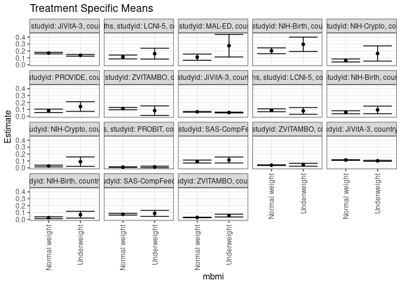

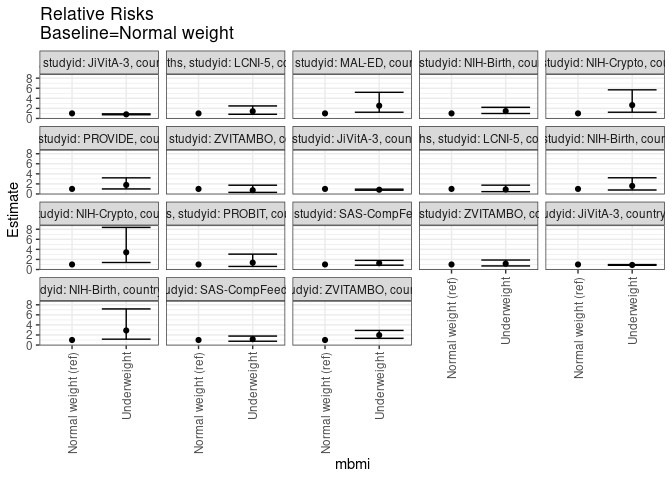

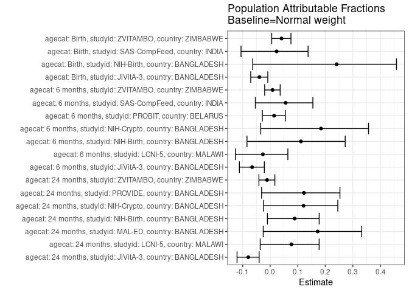

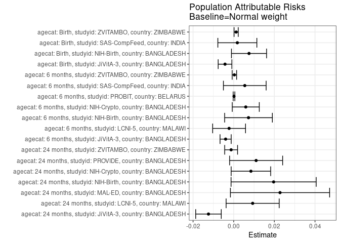

## Results Table

### Parameter: TSM

| agecat | studyid | country | intervention_level | baseline_level | estimate | ci_lower | ci_upper |
| --- | --- | --- | --- | --- | --- | --- | --- |
| Birth | JiVitA-3 | BANGLADESH | Normal weight | NA | 0.1132403 | 0.1075079 | 0.1189728 |
| Birth | JiVitA-3 | BANGLADESH | Underweight | NA | 0.1021776 | 0.0951854 | 0.1091699 |
| Birth | NIH-Birth | BANGLADESH | Normal weight | NA | 0.0237154 | 0.0104465 | 0.0369843 |
| Birth | NIH-Birth | BANGLADESH | Underweight | NA | 0.0686275 | 0.0195235 | 0.1177314 |
| Birth | SAS-CompFeed | INDIA | Normal weight | NA | 0.0748632 | 0.0624553 | 0.0872710 |
| Birth | SAS-CompFeed | INDIA | Underweight | NA | 0.0866389 | 0.0432542 | 0.1300236 |
| Birth | ZVITAMBO | ZIMBABWE | Normal weight | NA | 0.0280581 | 0.0246743 | 0.0314419 |
| Birth | ZVITAMBO | ZIMBABWE | Underweight | NA | 0.0551805 | 0.0347122 | 0.0756488 |
| 6 months | JiVitA-3 | BANGLADESH | Normal weight | NA | 0.0646622 | 0.0598275 | 0.0694969 |
| 6 months | JiVitA-3 | BANGLADESH | Underweight | NA | 0.0542714 | 0.0485058 | 0.0600370 |
| 6 months | LCNI-5 | MALAWI | Normal weight | NA | 0.0871955 | 0.0661847 | 0.1082064 |
| 6 months | LCNI-5 | MALAWI | Underweight | NA | 0.0781227 | 0.0296224 | 0.1266231 |
| 6 months | NIH-Birth | BANGLADESH | Normal weight | NA | 0.0578985 | 0.0358982 | 0.0798988 |
| 6 months | NIH-Birth | BANGLADESH | Underweight | NA | 0.0922350 | 0.0372216 | 0.1472484 |
| 6 months | NIH-Crypto | BANGLADESH | Normal weight | NA | 0.0262346 | 0.0139197 | 0.0385494 |
| 6 months | NIH-Crypto | BANGLADESH | Underweight | NA | 0.0895522 | 0.0211327 | 0.1579718 |
| 6 months | PROBIT | BELARUS | Normal weight | NA | 0.0101438 | 0.0048430 | 0.0154445 |
| 6 months | PROBIT | BELARUS | Underweight | NA | 0.0138614 | 0.0024257 | 0.0252970 |
| 6 months | SAS-CompFeed | INDIA | Normal weight | NA | 0.0914590 | 0.0698901 | 0.1130278 |
| 6 months | SAS-CompFeed | INDIA | Underweight | NA | 0.1138399 | 0.0706321 | 0.1570478 |
| 6 months | ZVITAMBO | ZIMBABWE | Normal weight | NA | 0.0387192 | 0.0341977 | 0.0432406 |
| 6 months | ZVITAMBO | ZIMBABWE | Underweight | NA | 0.0446684 | 0.0234428 | 0.0658940 |
| 24 months | JiVitA-3 | BANGLADESH | Normal weight | NA | 0.1684814 | 0.1571555 | 0.1798073 |
| 24 months | JiVitA-3 | BANGLADESH | Underweight | NA | 0.1365344 | 0.1239857 | 0.1490830 |
| 24 months | LCNI-5 | MALAWI | Normal weight | NA | 0.1119947 | 0.0838824 | 0.1401069 |
| 24 months | LCNI-5 | MALAWI | Underweight | NA | 0.1601548 | 0.0812585 | 0.2390510 |
| 24 months | MAL-ED | BANGLADESH | Normal weight | NA | 0.1092896 | 0.0639783 | 0.1546010 |
| 24 months | MAL-ED | BANGLADESH | Underweight | NA | 0.2758621 | 0.1128077 | 0.4389164 |
| 24 months | NIH-Birth | BANGLADESH | Normal weight | NA | 0.2018053 | 0.1599215 | 0.2436890 |
| 24 months | NIH-Birth | BANGLADESH | Underweight | NA | 0.2956539 | 0.1914152 | 0.3998925 |
| 24 months | NIH-Crypto | BANGLADESH | Normal weight | NA | 0.0615711 | 0.0398416 | 0.0833006 |
| 24 months | NIH-Crypto | BANGLADESH | Underweight | NA | 0.1627907 | 0.0523400 | 0.2732414 |
| 24 months | PROVIDE | BANGLADESH | Normal weight | NA | 0.0790864 | 0.0548005 | 0.1033723 |
| 24 months | PROVIDE | BANGLADESH | Underweight | NA | 0.1416373 | 0.0712699 | 0.2120047 |
| 24 months | ZVITAMBO | ZIMBABWE | Normal weight | NA | 0.1105183 | 0.0935466 | 0.1274900 |
| 24 months | ZVITAMBO | ZIMBABWE | Underweight | NA | 0.0819672 | 0.0131035 | 0.1508309 |

### Parameter: E(Y)

| agecat | studyid | country | intervention_level | baseline_level | estimate | ci_lower | ci_upper |
| --- | --- | --- | --- | --- | --- | --- | --- |
| Birth | JiVitA-3 | BANGLADESH | NA | NA | 0.1089689 | 0.1044172 | 0.1135206 |
| Birth | NIH-Birth | BANGLADESH | NA | NA | 0.0312500 | 0.0174085 | 0.0450915 |
| Birth | SAS-CompFeed | INDIA | NA | NA | 0.0766520 | 0.0591565 | 0.0941474 |
| Birth | ZVITAMBO | ZIMBABWE | NA | NA | 0.0292597 | 0.0259008 | 0.0326186 |
| 6 months | JiVitA-3 | BANGLADESH | NA | NA | 0.0606802 | 0.0568207 | 0.0645397 |
| 6 months | LCNI-5 | MALAWI | NA | NA | 0.0849282 | 0.0660197 | 0.1038368 |
| 6 months | NIH-Birth | BANGLADESH | NA | NA | 0.0651769 | 0.0442802 | 0.0860736 |
| 6 months | NIH-Crypto | BANGLADESH | NA | NA | 0.0321678 | 0.0192256 | 0.0451101 |
| 6 months | PROBIT | BELARUS | NA | NA | 0.0102879 | 0.0050246 | 0.0155512 |
| 6 months | SAS-CompFeed | INDIA | NA | NA | 0.0969055 | 0.0737418 | 0.1200693 |
| 6 months | ZVITAMBO | ZIMBABWE | NA | NA | 0.0390508 | 0.0346294 | 0.0434723 |
| 24 months | JiVitA-3 | BANGLADESH | NA | NA | 0.1560647 | 0.1473093 | 0.1648200 |
| 24 months | LCNI-5 | MALAWI | NA | NA | 0.1213172 | 0.0946539 | 0.1479805 |
| 24 months | MAL-ED | BANGLADESH | NA | NA | 0.1320755 | 0.0863920 | 0.1777589 |
| 24 months | NIH-Birth | BANGLADESH | NA | NA | 0.2214452 | 0.1821080 | 0.2607825 |
| 24 months | NIH-Crypto | BANGLADESH | NA | NA | 0.0700389 | 0.0479542 | 0.0921236 |
| 24 months | PROVIDE | BANGLADESH | NA | NA | 0.0901213 | 0.0667360 | 0.1135066 |
| 24 months | ZVITAMBO | ZIMBABWE | NA | NA | 0.1092498 | 0.0927432 | 0.1257565 |

### Parameter: RR

| agecat | studyid | country | intervention_level | baseline_level | estimate | ci_lower | ci_upper |
| --- | --- | --- | --- | --- | --- | --- | --- |
| Birth | JiVitA-3 | BANGLADESH | Normal weight | Normal weight | 1.0000000 | 1.0000000 | 1.0000000 |
| Birth | JiVitA-3 | BANGLADESH | Underweight | Normal weight | 0.9023078 | 0.8308870 | 0.9798678 |
| Birth | NIH-Birth | BANGLADESH | Normal weight | Normal weight | 1.0000000 | 1.0000000 | 1.0000000 |
| Birth | NIH-Birth | BANGLADESH | Underweight | Normal weight | 2.8937908 | 1.1668052 | 7.1768839 |
| Birth | SAS-CompFeed | INDIA | Normal weight | Normal weight | 1.0000000 | 1.0000000 | 1.0000000 |
| Birth | SAS-CompFeed | INDIA | Underweight | Normal weight | 1.1572972 | 0.7519140 | 1.7812369 |
| Birth | ZVITAMBO | ZIMBABWE | Normal weight | Normal weight | 1.0000000 | 1.0000000 | 1.0000000 |
| Birth | ZVITAMBO | ZIMBABWE | Underweight | Normal weight | 1.9666511 | 1.3313937 | 2.9050135 |
| 6 months | JiVitA-3 | BANGLADESH | Normal weight | Normal weight | 1.0000000 | 1.0000000 | 1.0000000 |
| 6 months | JiVitA-3 | BANGLADESH | Underweight | Normal weight | 0.8393057 | 0.7415381 | 0.9499634 |
| 6 months | LCNI-5 | MALAWI | Normal weight | Normal weight | 1.0000000 | 1.0000000 | 1.0000000 |
| 6 months | LCNI-5 | MALAWI | Underweight | Normal weight | 0.8959488 | 0.4604053 | 1.7435166 |
| 6 months | NIH-Birth | BANGLADESH | Normal weight | Normal weight | 1.0000000 | 1.0000000 | 1.0000000 |
| 6 months | NIH-Birth | BANGLADESH | Underweight | Normal weight | 1.5930470 | 0.7873676 | 3.2231434 |
| 6 months | NIH-Crypto | BANGLADESH | Normal weight | Normal weight | 1.0000000 | 1.0000000 | 1.0000000 |
| 6 months | NIH-Crypto | BANGLADESH | Underweight | Normal weight | 3.4135206 | 1.3924201 | 8.3682526 |
| 6 months | PROBIT | BELARUS | Normal weight | Normal weight | 1.0000000 | 1.0000000 | 1.0000000 |
| 6 months | PROBIT | BELARUS | Underweight | Normal weight | 1.3664926 | 0.6117741 | 3.0522737 |
| 6 months | SAS-CompFeed | INDIA | Normal weight | Normal weight | 1.0000000 | 1.0000000 | 1.0000000 |
| 6 months | SAS-CompFeed | INDIA | Underweight | Normal weight | 1.2447103 | 0.8522862 | 1.8178210 |
| 6 months | ZVITAMBO | ZIMBABWE | Normal weight | Normal weight | 1.0000000 | 1.0000000 | 1.0000000 |
| 6 months | ZVITAMBO | ZIMBABWE | Underweight | Normal weight | 1.1536509 | 0.7072222 | 1.8818844 |
| 24 months | JiVitA-3 | BANGLADESH | Normal weight | Normal weight | 1.0000000 | 1.0000000 | 1.0000000 |
| 24 months | JiVitA-3 | BANGLADESH | Underweight | Normal weight | 0.8103824 | 0.7259002 | 0.9046968 |
| 24 months | LCNI-5 | MALAWI | Normal weight | Normal weight | 1.0000000 | 1.0000000 | 1.0000000 |
| 24 months | LCNI-5 | MALAWI | Underweight | Normal weight | 1.4300216 | 0.8236117 | 2.4829197 |
| 24 months | MAL-ED | BANGLADESH | Normal weight | Normal weight | 1.0000000 | 1.0000000 | 1.0000000 |
| 24 months | MAL-ED | BANGLADESH | Underweight | Normal weight | 2.5241379 | 1.2261968 | 5.1959623 |
| 24 months | NIH-Birth | BANGLADESH | Normal weight | Normal weight | 1.0000000 | 1.0000000 | 1.0000000 |
| 24 months | NIH-Birth | BANGLADESH | Underweight | Normal weight | 1.4650454 | 0.9745095 | 2.2025008 |
| 24 months | NIH-Crypto | BANGLADESH | Normal weight | Normal weight | 1.0000000 | 1.0000000 | 1.0000000 |
| 24 months | NIH-Crypto | BANGLADESH | Underweight | Normal weight | 2.6439455 | 1.2305873 | 5.6805785 |
| 24 months | PROVIDE | BANGLADESH | Normal weight | Normal weight | 1.0000000 | 1.0000000 | 1.0000000 |
| 24 months | PROVIDE | BANGLADESH | Underweight | Normal weight | 1.7909185 | 0.9995335 | 3.2088858 |
| 24 months | ZVITAMBO | ZIMBABWE | Normal weight | Normal weight | 1.0000000 | 1.0000000 | 1.0000000 |
| 24 months | ZVITAMBO | ZIMBABWE | Underweight | Normal weight | 0.7416620 | 0.3157140 | 1.7422810 |

### Parameter: PAR

| agecat | studyid | country | intervention_level | baseline_level | estimate | ci_lower | ci_upper |
| --- | --- | --- | --- | --- | --- | --- | --- |
| Birth | JiVitA-3 | BANGLADESH | Normal weight | NA | -0.0042714 | -0.0076459 | -0.0008970 |
| Birth | NIH-Birth | BANGLADESH | Normal weight | NA | 0.0075346 | -0.0011025 | 0.0161717 |
| Birth | SAS-CompFeed | INDIA | Normal weight | NA | 0.0017888 | -0.0078064 | 0.0113840 |
| Birth | ZVITAMBO | ZIMBABWE | Normal weight | NA | 0.0012016 | 0.0001716 | 0.0022316 |
| 6 months | JiVitA-3 | BANGLADESH | Normal weight | NA | -0.0039820 | -0.0067286 | -0.0012355 |
| 6 months | LCNI-5 | MALAWI | Normal weight | NA | -0.0022673 | -0.0103573 | 0.0058227 |
| 6 months | NIH-Birth | BANGLADESH | Normal weight | NA | 0.0072784 | -0.0044604 | 0.0190173 |
| 6 months | NIH-Crypto | BANGLADESH | Normal weight | NA | 0.0059333 | -0.0007202 | 0.0125867 |
| 6 months | PROBIT | BELARUS | Normal weight | NA | 0.0001441 | -0.0002744 | 0.0005626 |
| 6 months | SAS-CompFeed | INDIA | Normal weight | NA | 0.0054466 | -0.0050657 | 0.0159588 |
| 6 months | ZVITAMBO | ZIMBABWE | Normal weight | NA | 0.0003317 | -0.0007650 | 0.0014283 |
| 24 months | JiVitA-3 | BANGLADESH | Normal weight | NA | -0.0124167 | -0.0187083 | -0.0061252 |
| 24 months | LCNI-5 | MALAWI | Normal weight | NA | 0.0093225 | -0.0037385 | 0.0223835 |
| 24 months | MAL-ED | BANGLADESH | Normal weight | NA | 0.0227859 | -0.0016183 | 0.0471900 |
| 24 months | NIH-Birth | BANGLADESH | Normal weight | NA | 0.0196400 | -0.0013085 | 0.0405884 |
| 24 months | NIH-Crypto | BANGLADESH | Normal weight | NA | 0.0084678 | -0.0012566 | 0.0181922 |
| 24 months | PROVIDE | BANGLADESH | Normal weight | NA | 0.0110349 | -0.0020089 | 0.0240787 |
| 24 months | ZVITAMBO | ZIMBABWE | Normal weight | NA | -0.0012685 | -0.0044349 | 0.0018979 |

### Parameter: PAF

| agecat | studyid | country | intervention_level | baseline_level | estimate | ci_lower | ci_upper |
| --- | --- | --- | --- | --- | --- | --- | --- |
| Birth | JiVitA-3 | BANGLADESH | Normal weight | NA | -0.0391985 | -0.0706347 | -0.0086853 |
| Birth | NIH-Birth | BANGLADESH | Normal weight | NA | 0.2411067 | -0.0633857 | 0.4584100 |
| Birth | SAS-CompFeed | INDIA | Normal weight | NA | 0.0233369 | -0.1058851 | 0.1374595 |
| Birth | ZVITAMBO | ZIMBABWE | Normal weight | NA | 0.0410672 | 0.0055156 | 0.0753479 |
| 6 months | JiVitA-3 | BANGLADESH | Normal weight | NA | -0.0656235 | -0.1118692 | -0.0213013 |
| 6 months | LCNI-5 | MALAWI | Normal weight | NA | -0.0266966 | -0.1263215 | 0.0641163 |
| 6 months | NIH-Birth | BANGLADESH | Normal weight | NA | 0.1116721 | -0.0842402 | 0.2721848 |
| 6 months | NIH-Crypto | BANGLADESH | Normal weight | NA | 0.1844471 | -0.0343640 | 0.3569706 |
| 6 months | PROBIT | BELARUS | Normal weight | NA | 0.0140104 | -0.0285400 | 0.0548005 |
| 6 months | SAS-CompFeed | INDIA | Normal weight | NA | 0.0562049 | -0.0539770 | 0.1548684 |
| 6 months | ZVITAMBO | ZIMBABWE | Normal weight | NA | 0.0084934 | -0.0199763 | 0.0361684 |
| 24 months | JiVitA-3 | BANGLADESH | Normal weight | NA | -0.0795615 | -0.1203871 | -0.0402235 |
| 24 months | LCNI-5 | MALAWI | Normal weight | NA | 0.0768440 | -0.0363440 | 0.1776697 |
| 24 months | MAL-ED | BANGLADESH | Normal weight | NA | 0.1725215 | -0.0253527 | 0.3322096 |
| 24 months | NIH-Birth | BANGLADESH | Normal weight | NA | 0.0886899 | -0.0099839 | 0.1777234 |
| 24 months | NIH-Crypto | BANGLADESH | Normal weight | NA | 0.1209012 | -0.0241135 | 0.2453817 |
| 24 months | PROVIDE | BANGLADESH | Normal weight | NA | 0.1224449 | -0.0311763 | 0.2531801 |
| 24 months | ZVITAMBO | ZIMBABWE | Normal weight | NA | -0.0116108 | -0.0409718 | 0.0169221 |